# Quick R demo

Hicham Zmarrou

2017-09-26

In order to illustrate how the R workflow `Import, Tidy, Transform, Visualize, Model and comminicate` works. we explore `nycflights13` a small dataset of all flights departing from NYC in 2013. It also includes useful ‘metadata’ on airlines, airports, weather, and planes. This dataset is included in the R package with the same name.

```r
# install.packages("highcharter")
options(warn=-1)
suppressWarnings(suppressPackageStartupMessages(library(highcharter)))
suppressWarnings(suppressPackageStartupMessages(library(lubridate)))
suppressWarnings(suppressPackageStartupMessages(library(xts)))
suppressWarnings(suppressPackageStartupMessages(library(lattice)))
suppressWarnings(suppressPackageStartupMessages(library(mosaic)))
suppressWarnings(suppressPackageStartupMessages(library(tidyverse)))
library(nycflights13)
airlines
```

```
## # A tibble: 16 x 2
##    carrier                        name
##      <chr>                       <chr>
##  1      9E           Endeavor Air Inc.
##  2      AA      American Airlines Inc.
##  3      AS        Alaska Airlines Inc.
##  4      B6             JetBlue Airways
##  5      DL        Delta Air Lines Inc.
##  6      EV    ExpressJet Airlines Inc.
##  7      F9      Frontier Airlines Inc.
##  8      FL AirTran Airways Corporation
##  9      HA      Hawaiian Airlines Inc.
## 10      MQ                   Envoy Air
## 11      OO       SkyWest Airlines Inc.
## 12      UA       United Air Lines Inc.
## 13      US             US Airways Inc.
## 14      VX              Virgin America
## 15      WN      Southwest Airlines Co.
## 16      YV          Mesa Airlines Inc.
```

```r
airports
```

```
## # A tibble: 1,458 x 8
##      faa                           name      lat        lon   alt    tz
##    <chr>                          <chr>    <dbl>      <dbl> <int> <dbl>
##  1   04G              Lansdowne Airport 41.13047  -80.61958  1044    -5
##  2   06A  Moton Field Municipal Airport 32.46057  -85.68003   264    -6
##  3   06C            Schaumburg Regional 41.98934  -88.10124   801    -6
##  4   06N                Randall Airport 41.43191  -74.39156   523    -5
##  5   09J          Jekyll Island Airport 31.07447  -81.42778    11    -5
##  6   0A9 Elizabethton Municipal Airport 36.37122  -82.17342  1593    -5
##  7   0G6        Williams County Airport 41.46731  -84.50678   730    -5
##  8   0G7  Finger Lakes Regional Airport 42.88356  -76.78123   492    -5
##  9   0P2   Shoestring Aviation Airfield 39.79482  -76.64719  1000    -5
## 10   0S9          Jefferson County Intl 48.05381 -122.81064   108    -8
## # ... with 1,448 more rows, and 2 more variables: dst <chr>, tzone <chr>
```

```r
planes
```

```
## # A tibble: 3,322 x 9
##    tailnum  year                    type     manufacturer     model
##      <chr> <int>                   <chr>            <chr>     <chr>
##  1  N10156  2004 Fixed wing multi engine          EMBRAER EMB-145XR
##  2  N102UW  1998 Fixed wing multi engine AIRBUS INDUSTRIE  A320-214
##  3  N103US  1999 Fixed wing multi engine AIRBUS INDUSTRIE  A320-214
##  4  N104UW  1999 Fixed wing multi engine AIRBUS INDUSTRIE  A320-214
##  5  N10575  2002 Fixed wing multi engine          EMBRAER EMB-145LR
##  6  N105UW  1999 Fixed wing multi engine AIRBUS INDUSTRIE  A320-214
##  7  N107US  1999 Fixed wing multi engine AIRBUS INDUSTRIE  A320-214
##  8  N108UW  1999 Fixed wing multi engine AIRBUS INDUSTRIE  A320-214
##  9  N109UW  1999 Fixed wing multi engine AIRBUS INDUSTRIE  A320-214
## 10  N110UW  1999 Fixed wing multi engine AIRBUS INDUSTRIE  A320-214
## # ... with 3,312 more rows, and 4 more variables: engines <int>,
## #   seats <int>, speed <int>, engine <chr>
```

```r
flights
```

```
## # A tibble: 336,776 x 19
##     year month   day dep_time sched_dep_time dep_delay arr_time
##    <int> <int> <int>    <int>          <int>     <dbl>    <int>
##  1  2013     1     1      517            515         2      830
##  2  2013     1     1      533            529         4      850
##  3  2013     1     1      542            540         2      923
##  4  2013     1     1      544            545        -1     1004
##  5  2013     1     1      554            600        -6      812
##  6  2013     1     1      554            558        -4      740
##  7  2013     1     1      555            600        -5      913
##  8  2013     1     1      557            600        -3      709
##  9  2013     1     1      557            600        -3      838
## 10  2013     1     1      558            600        -2      753
## # ... with 336,766 more rows, and 12 more variables: sched_arr_time <int>,
## #   arr_delay <dbl>, carrier <chr>, flight <int>, tailnum <chr>,
## #   origin <chr>, dest <chr>, air_time <dbl>, distance <dbl>, hour <dbl>,
## #   minute <dbl>, time_hour <dttm>
```

```r
nycflights13::weather
```

```
## # A tibble: 26,130 x 15
##    origin  year month   day  hour  temp  dewp humid wind_dir wind_speed
##     <chr> <dbl> <dbl> <int> <int> <dbl> <dbl> <dbl>    <dbl>      <dbl>
##  1    EWR  2013     1     1     0 37.04 21.92 53.97      230   10.35702
##  2    EWR  2013     1     1     1 37.04 21.92 53.97      230   13.80936
##  3    EWR  2013     1     1     2 37.94 21.92 52.09      230   12.65858
##  4    EWR  2013     1     1     3 37.94 23.00 54.51      230   13.80936
##  5    EWR  2013     1     1     4 37.94 24.08 57.04      240   14.96014
##  6    EWR  2013     1     1     6 39.02 26.06 59.37      270   10.35702
##  7    EWR  2013     1     1     7 39.02 26.96 61.63      250    8.05546
##  8    EWR  2013     1     1     8 39.02 28.04 64.43      240   11.50780
##  9    EWR  2013     1     1     9 39.92 28.04 62.21      250   12.65858
## 10    EWR  2013     1     1    10 39.02 28.04 64.43      260   12.65858
## # ... with 26,120 more rows, and 5 more variables: wind_gust <dbl>,
## #   precip <dbl>, pressure <dbl>, visib <dbl>, time_hour <dttm>
```

Here we illustrate how the `tidyrverse` package in R can be used to build a powerful and broadly accessible foundation for data manipulation. This approach is attractive because it provides simple functions that correspond to the most common data manipulation operations (or *verbs*) and uses efficient storage approaches so that the analyst can focus on the analysis.

```
verb          meaning
--------------------------------------------
select()      select variables (or columns)
filter()      subset observations (or rows)
mutate()      add new variables (or columns)
arrange()     re-order the observations
summarise()   reduce to a single row
group_by()    aggregate
left_join()   merge two data objects
distinct()    remove duplicate entries
collect()     force computation and bring data back into R
```

Table 1: Key verbs in `dplyr` and `tidyr` to support data management and manipulation (see http://r4ds.had.co.nz/ for more details)

### Airline delays

We demonstrate how to undertake analysis using the tools in the `dplyr` package. A smaller dataset is available for n=336,776 New York City flights in 2013 within the `nycflights13` package. The interface in R accessing the full database is almost identical in terms of the `dplyr` functionality, with the same functions being used.

course participants can use this dataset to address questions that they find real and relevant. (It is not hard to find motivation for investigating patterns of flight delays.

We begin by loading needed packages and connecting to a database containing the flight, airline, airport, and airplane data.

### Filtering observations

- We start with an analysis focused on three smaller airports in the Northeast.
- This illustrates the use of `filter()`, which allows the specification of a subset of rows of interest in the `airports` table (or dataset).
- We first start by exploring the `airports` table. Suppose we wanted to find out which airports certain codes belong to?

```r
airports <- tbl_df(airports)
filter(airports, faa %in% c('ALB', 'BDL', 'BTV'))
```

```
## # A tibble: 3 x 8
##     faa            name      lat       lon   alt    tz   dst
##   <chr>           <chr>    <dbl>     <dbl> <int> <dbl> <chr>
## 1   ALB     Albany Intl 42.74827 -73.80169   285    -5     A
## 2   BDL    Bradley Intl 41.93889 -72.68322   173    -5     A
## 3   BTV Burlington Intl 44.47186 -73.15328   335    -5     A
## # ... with 1 more variables: tzone <chr>
```

Next we aggregate the counts of flights at all three of these airports at the monthly level (in the `ontime` flight-level table), using the `group_by()` and `summarise()` functions. The `collect()` function forces the evaluation. These functions are connected using the `%>%` operator. This pipes the results from one object or function as input to the next in an efficient manner.

```r
airportcounts <- flights %>%
filter(dest %in% c('ALB', 'BDL', 'BTV')) %>%
group_by(year, month, dest) %>%
summarise(count = n()) %>%
collect()
airportcounts
```

```
## # A tibble: 36 x 4
## # Groups:   year, month [?]
##     year month  dest count
##    <int> <int> <chr> <int>
##  1  2013     1   ALB    64
##  2  2013     1   BDL    37
##  3  2013     1   BTV   223
##  4  2013     2   ALB    58
##  5  2013     2   BDL    46
##  6  2013     2   BTV   189
##  7  2013     3   ALB    57
##  8  2013     3   BDL    62
##  9  2013     3   BTV   257
## 10  2013     4   ALB    13
## # ... with 26 more rows
```

### Creating new derived variables

Next we add a new column by constructing a date variable (using `mutate()` and helper functions from the `lubridate` package), then generate a time series plot.

```r
airportcounts <- airportcounts %>%
  mutate(Date = ymd(paste(year, "-", month, "-01", sep="")))
head(airportcounts) # list only the first six observations
```

```
## # A tibble: 6 x 5
## # Groups:   year, month [2]
##    year month  dest count       Date
##   <int> <int> <chr> <int>     <date>
## 1  2013     1   ALB    64 2013-01-01
## 2  2013     1   BDL    37 2013-01-01
## 3  2013     1   BTV   223 2013-01-01
## 4  2013     2   ALB    58 2013-02-01
## 5  2013     2   BDL    46 2013-02-01
## 6  2013     2   BTV   189 2013-02-01
```

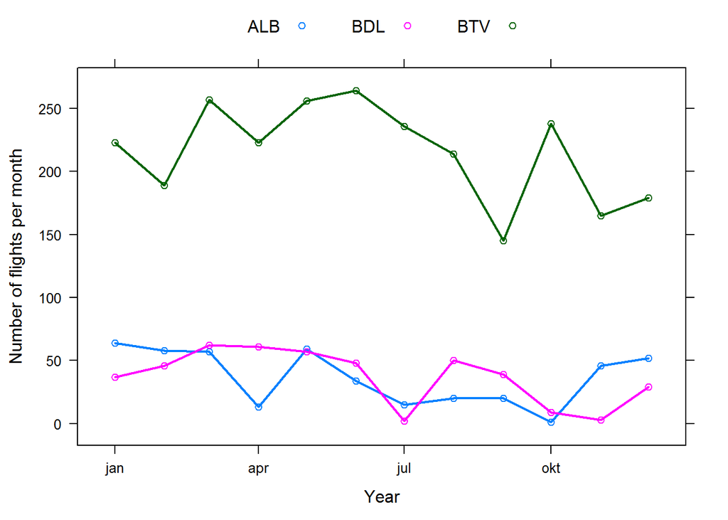

```r
## lattice
xyplot(count ~ Date, groups=dest, type=c("p","l"), lwd=2,
       auto.key=list(columns=3), xlab="Year",
       ylab="Number of flights per month", data=airportcounts)
```

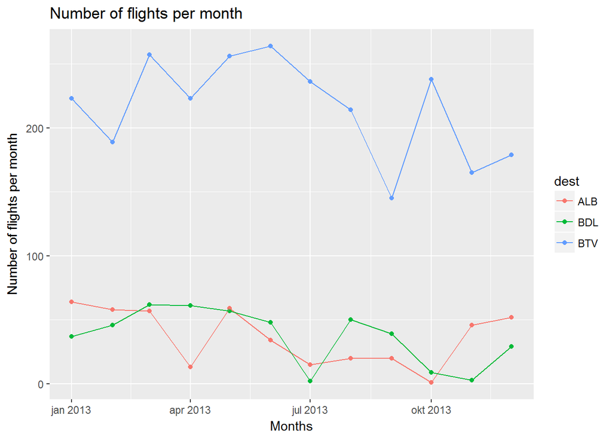

```r
## ggplot2
ggplot(data=airportcounts,aes(x=Date,y=count,colour=dest,group=dest)) + geom_point()+ geom_line() +
ggtitle("Number of flights per month") + theme(plot.title = element_text(lineheight=.8)) + xlab("Months") + ylab("Number of flights per month")
```

```r
  # wrote a custom ylab
## Highcharter
wide_airportcounts <- airportcounts %>% spread(dest, count)
wide_airportcounts$year <- NULL
wide_airportcounts$month <- NULL
wide_airportcounts$Date <- as.Date(as.character(wide_airportcounts$Date), "%Y-%m-%d")
wide_airportcounts <- xts(wide_airportcounts[,-1], wide_airportcounts$Date)

highchart(type = "stock") %>%
  hc_title(text = "Number of flights per month") %>%
  hc_add_series(wide_airportcounts[,1], name = "ALB") %>%
  hc_add_series(wide_airportcounts[,2], name = "BDL") %>%
  hc_add_series(wide_airportcounts[,3], name = "BTV")
```

[interactive chart not shown]

We observe in this figure that there are some interesting patterns over time for these airports. Burlington has the largest number of flights.

Another important verb is arrange(), which in conjunction with head() lets us display the months with the largest number of flights. Here we need to use ungroup(), since otherwise the data would remain aggregated by year, month, and destination.

```r
airportcounts %>%
ungroup() %>%
arrange(desc(count)) %>%
select(count, year, month, dest) %>%
head()
```

```
## # A tibble: 6 x 4
##   count  year month  dest
##   <int> <int> <int> <chr>
## 1   264  2013     6   BTV
## 2   257  2013     3   BTV
## 3   256  2013     5   BTV
## 4   238  2013    10   BTV
## 5   236  2013     7   BTV
## 6   223  2013     1   BTV
```

For example, which airline was most reliable flying from New York to Minneapolis/St. Paul (MSP) in January, 2013? Here we demonstrate how to calculate an average delay for each day . We create the analytic dataset through use of select() (to pick the variables to be included), filter() (to select a tiny subset of the observations), and then repeat the previous aggregation.

```r
delays <- flights %>%
select(origin, dest, year, month, day, carrier, arr_delay) %>%
filter(dest == 'MSP' & month == 1) %>%
group_by(year, month, day, carrier) %>%
summarise(meandelay = mean(arr_delay), count = n())
delays
```

```
## # A tibble: 124 x 6
## # Groups:   year, month, day [?]
##     year month   day carrier  meandelay count
##    <int> <int> <int>   <chr>      <dbl> <int>
##  1  2013     1     1      9E  25.000000     2
##  2  2013     1     1      DL  -5.285714     7
##  3  2013     1     1      EV  29.000000     1
##  4  2013     1     1      MQ  69.250000     4
##  5  2013     1     2      9E   7.500000     2
##  6  2013     1     2      DL  -3.333333     9
##  7  2013     1     2      EV  15.500000     2
##  8  2013     1     2      MQ  -4.500000     4
##  9  2013     1     3      9E  -0.750000     4
## 10  2013     1     3      DL -10.857143     7
## # ... with 114 more rows
```

```r
options(digits=3)
favstats(~ meandelay, data=delays)
```

```
##  min    Q1 median   Q3 max mean   sd   n missing
##  -22 -5.51   4.12 22.6 133 11.1 23.8 112      12
```

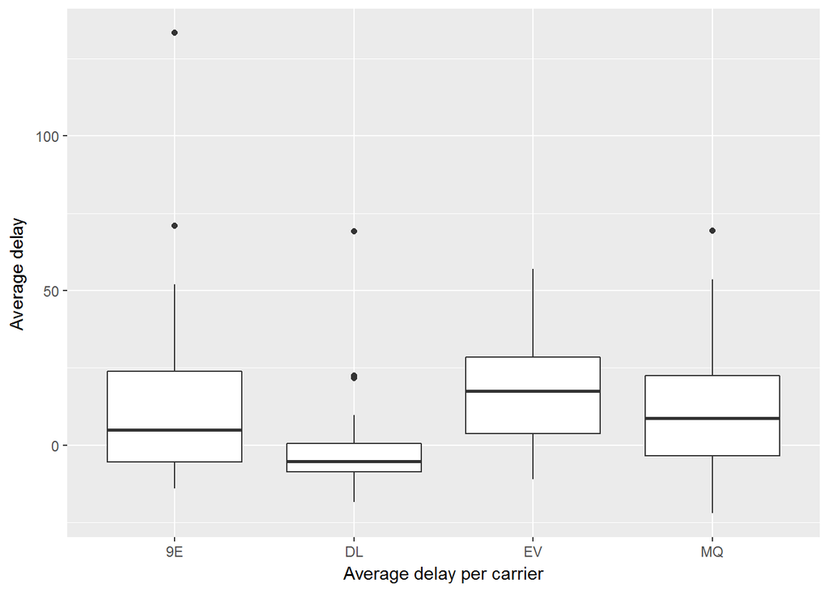

```r
## ggplot
ggplot(data=delays, aes(x=carrier, y=meandelay)) +
  # plot the boxplots
  geom_boxplot() +
  # write a custom xlab
  xlab("Average delay per carrier") +
  # write a custom ylab
  ylab("Average delay")
```

```r
## highcharter
hcboxplot(var = delays$carrier, x = delays$meandelay, color = "blue")
```

[interactive chart not shown]

**Merging**: Merging is another key capacity to master. Here, the full carrier names are merged (or joined, in database languages) to facilitate the comparison, using the left_join() function to provide a less terse full name for the airlines in the legend of the figure.

```r
merged <- left_join(delays, airlines, by=c("carrier" = "carrier"))
#left_join(x,y): Include all of x, and matching rows of y
merged
```

```
## # A tibble: 124 x 7
## # Groups:   year, month, day [?]
##     year month   day carrier meandelay count                     name
##    <int> <int> <int>   <chr>     <dbl> <int>                    <chr>
##  1  2013     1     1      9E     25.00     2        Endeavor Air Inc.
##  2  2013     1     1      DL     -5.29     7     Delta Air Lines Inc.
##  3  2013     1     1      EV     29.00     1 ExpressJet Airlines Inc.
##  4  2013     1     1      MQ     69.25     4                Envoy Air
##  5  2013     1     2      9E      7.50     2        Endeavor Air Inc.
##  6  2013     1     2      DL     -3.33     9     Delta Air Lines Inc.
##  7  2013     1     2      EV     15.50     2 ExpressJet Airlines Inc.
##  8  2013     1     2      MQ     -4.50     4                Envoy Air
##  9  2013     1     3      9E     -0.75     4        Endeavor Air Inc.
## 10  2013     1     3      DL    -10.86     7     Delta Air Lines Inc.
## # ... with 114 more rows
```

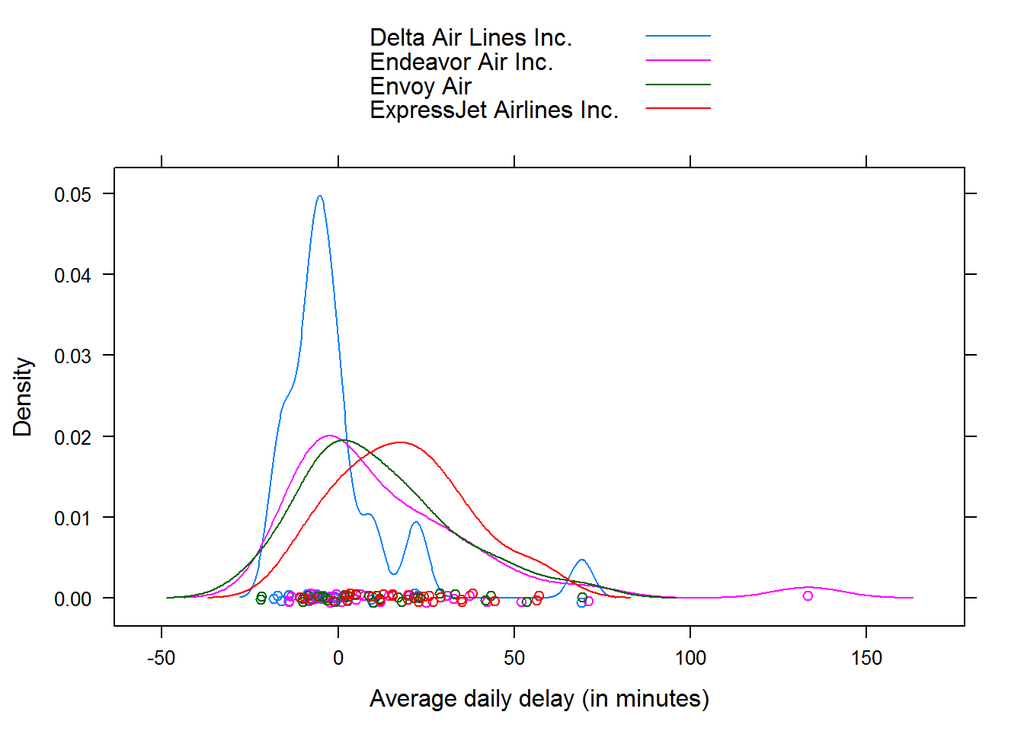

```r
densityplot(~ meandelay, group=name, auto.key=TRUE,
xlab="Average daily delay (in minutes)", data=merged)
```

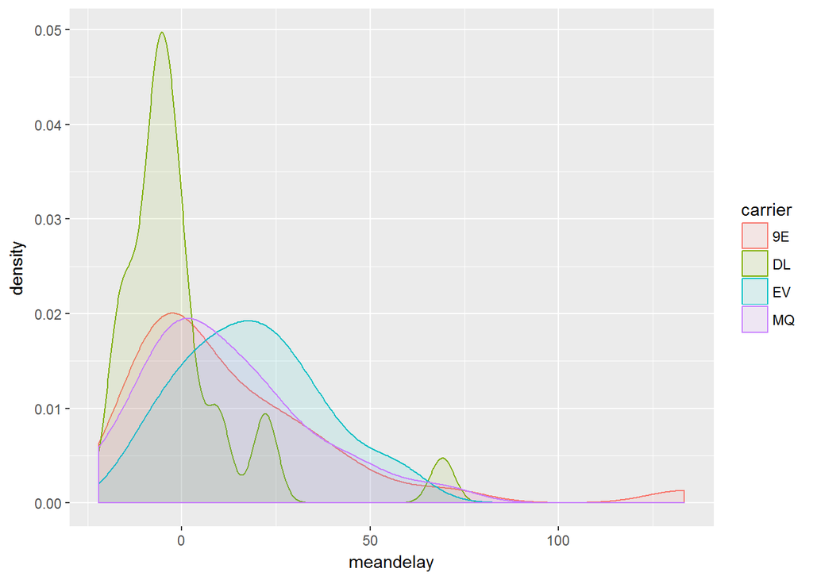

```r
ggplot( data=merged, aes(meandelay, fill = carrier, colour = carrier)) +
  geom_density(alpha = 0.1)
```

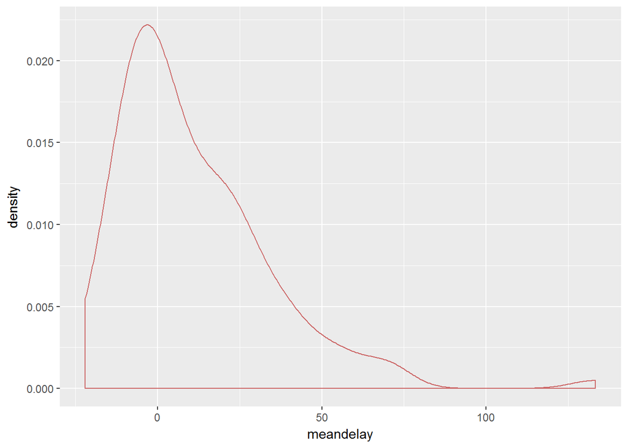

```r
ggplot(data=merged, aes(meandelay)) + geom_density(alpha = 0.2, colour = "#CC6666")
```

```r
#ggplot(data=merged, aes(meandelay)) + geom_density(alpha = 0, colour = "#F0E442")
```

We see in the figure that the airlines are fairly reliable, though there were some days with average delays of 60 minutes or more.

```r
filter(merged, meandelay > 60) %>% arrange(desc(meandelay))
```

```
## # A tibble: 4 x 7
## # Groups:   year, month, day [4]
##    year month   day carrier meandelay count                 name
##   <int> <int> <int>   <chr>     <dbl> <int>                <chr>
## 1  2013     1    16      9E     133.3     3    Endeavor Air Inc.
## 2  2013     1    30      9E      71.0     3    Endeavor Air Inc.
## 3  2013     1     1      MQ      69.2     4            Envoy Air
## 4  2013     1    23      DL      69.1     7 Delta Air Lines Inc.
```

Other data wrangling and manipulation capacities can be introduced and developed using this example, including more elaborate data joins/merges (since there are tables providing additional (meta)data about planes). As an example, consider the the plane with tailnum N355NB.

```r
filter(planes, tailnum=="N355NB")
```

```
## # A tibble: 1 x 9
##   tailnum  year                    type manufacturer    model engines
##     <chr> <int>                   <chr>        <chr>    <chr>   <int>
## 1  N355NB  2002 Fixed wing multi engine       AIRBUS A319-114       2
## # ... with 3 more variables: seats <int>, speed <int>, engine <chr>
```

We see that this is an Airbus 319.

```r
singleplane <- filter(flights, tailnum=="N355NB") %>%
  select(year, month, day, dest, origin, distance)

sum(~ distance, data=singleplane)
```

```
## [1] 106914
```

This Airbus A319 has been very active, with 128 flights just in 2013 in the New York City area.

```r
singleplane %>%
  group_by(dest) %>%
  summarise(count = n()) %>%
  arrange(desc(count)) %>% summarise(number_of_flight_N355NB = sum(count))
```

```
## # A tibble: 1 x 1
##   number_of_flight_N355NB
##                     <int>
## 1                     128
```

### Weather

Linkage to other data scraped from the Internet (e.g. detailed weather information for a particular airport or details about individual planes) may allow other questions to be answered.

```r
head(nycflights13::weather)
```

```
## # A tibble: 6 x 15
##   origin  year month   day  hour  temp  dewp humid wind_dir wind_speed
##    <chr> <dbl> <dbl> <int> <int> <dbl> <dbl> <dbl>    <dbl>      <dbl>
## 1    EWR  2013     1     1     0  37.0  21.9  54.0      230       10.4
## 2    EWR  2013     1     1     1  37.0  21.9  54.0      230       13.8
## 3    EWR  2013     1     1     2  37.9  21.9  52.1      230       12.7
## 4    EWR  2013     1     1     3  37.9  23.0  54.5      230       13.8
## 5    EWR  2013     1     1     4  37.9  24.1  57.0      240       15.0
## 6    EWR  2013     1     1     6  39.0  26.1  59.4      270       10.4
## # ... with 5 more variables: wind_gust <dbl>, precip <dbl>,
## #   pressure <dbl>, visib <dbl>, time_hour <dttm>
```

```r
# avgdelay per day
avgdelay <- flights %>%
  group_by(month, day) %>%
  filter(month < 13) %>%
  summarise(avgdelay = mean(arr_delay, na.rm=TRUE))

precip  <- nycflights13::weather %>%
  group_by(month, day) %>%
  filter(month < 13) %>%
  summarise(totprecip = sum(precip), maxwind = max(wind_speed))

precip <- mutate(precip, anyprecip = ifelse(totprecip==0, "No", "Yes"))

merged <- left_join(avgdelay, precip, by=c("day", "month"))
head(merged)
```

```
## # A tibble: 6 x 6
## # Groups:   month [1]
##   month   day avgdelay totprecip maxwind anyprecip
##   <dbl> <int>    <dbl>     <dbl>   <dbl>     <chr>
## 1     1     1    12.65         0    19.6        No
## 2     1     2    12.69         0    24.2        No
## 3     1     3     5.73         0    16.1        No
## 4     1     4    -1.93         0    24.2        No
## 5     1     5    -1.53         0    20.7        No
## 6     1     6     4.24         0    16.1        No
```

We can for example look at summary statistics for the wind:

```r
favstats(~ maxwind, data=merged)
```

```
##   min   Q1 median Q3  max mean   sd   n missing
##  9.21 16.1   19.6 23 1048 22.9 54.4 361       4
```

A dramatic outlier emerges: windspeeds of 1000 mph are not common!

```r
filter(merged, maxwind > 1000)
```

```
## # A tibble: 1 x 6
## # Groups:   month [1]
##   month   day avgdelay totprecip maxwind anyprecip
##   <dbl> <int>    <dbl>     <dbl>   <dbl>     <chr>
## 1     2    12    -2.14      0.01    1048       Yes
```

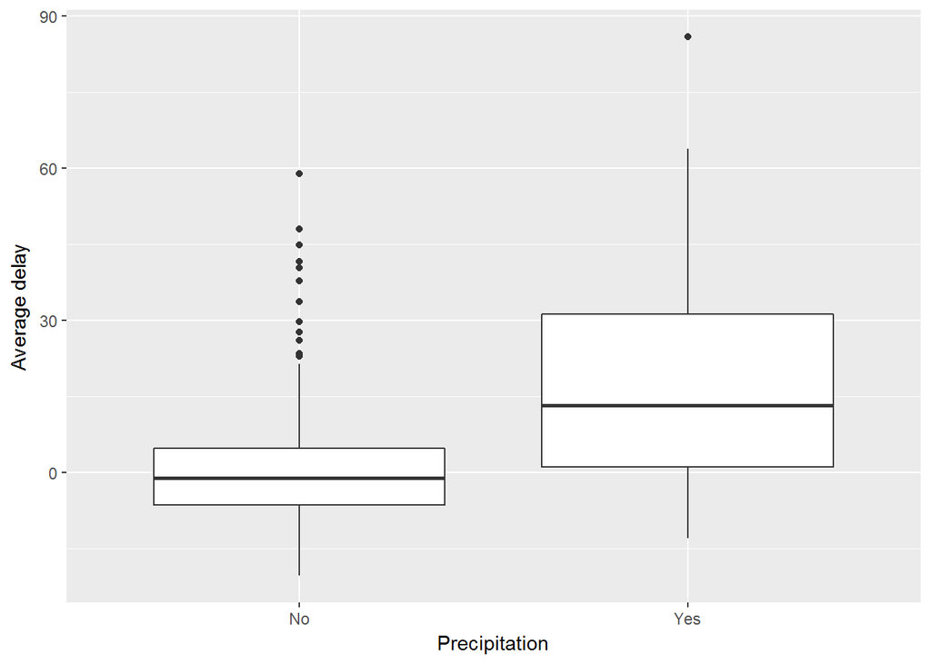

```r
merged <- filter(merged, maxwind < 1000)
# bwplot(avgdelay ~ anyprecip, data=merged)
ggplot(data=merged, aes(x=anyprecip, y=avgdelay)) +
  # plot the boxplots
  geom_boxplot() +
  # write a custom xlab
  xlab("Precipitation") +
  # wrote a custom ylab
  ylab("Average delay")
```

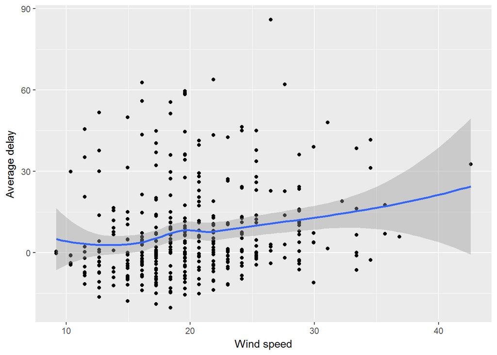

```r
ggplot(data=merged)+
  # plot the the points
  geom_point(mapping = aes(x=maxwind, y=avgdelay)) +
  # plot the the points
  geom_smooth(mapping = aes(x=maxwind, y=avgdelay))+
  # write a custom xlab
  xlab("Wind speed") +
  # wrote a custom ylab
  ylab("Average delay")
```

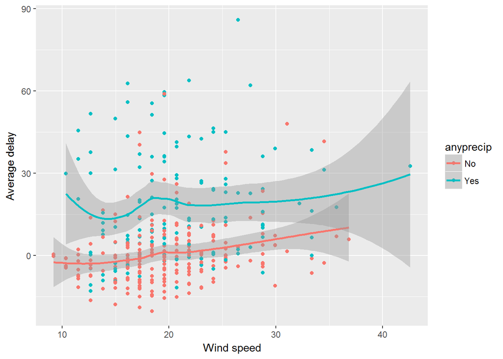

```r
ggplot(data=merged)+
  # plot the the points
  geom_point(mapping = aes(x=maxwind, y=avgdelay,color=anyprecip)) +
  # plot the the points
  geom_smooth(mapping = aes(x=maxwind, y=avgdelay,color=anyprecip))+
  # write a custom xlab
  xlab("Wind speed") +
  # wrote a custom ylab
  ylab("Average delay")
```

```r
# xyplot(avgdelay ~ maxwind, type=c("p", "smooth"), data=merged)
# xyplot(avgdelay ~ maxwind, groups=anyprecip, auto.key=TRUE, type=c("p", "smooth"), data=merged)
head(merged)
```

```
## # A tibble: 6 x 6
## # Groups:   month [1]
##   month   day avgdelay totprecip maxwind anyprecip
##   <dbl> <int>    <dbl>     <dbl>   <dbl>     <chr>
## 1     1     1    12.65         0    19.6        No
## 2     1     2    12.69         0    24.2        No
## 3     1     3     5.73         0    16.1        No
## 4     1     4    -1.93         0    24.2        No
## 5     1     5    -1.53         0    20.7        No
## 6     1     6     4.24         0    16.1        No
```

There is a modest relationship between average delay times and wind speed. The relationship is stronger between any precipitation (as seen in the last figure)

Use of this rich dataset helps to excite about the power of statistics, introduce tools that can help energize the next generation of data scientists, and build useful data-related skills.